# Analysis of PredictIt Strategies:

## Background on PredictIt

PredictIt is a political prediction market. In essence, what this means is that ordinary people are allowed to sign up and place bets on the outcome of political events.

There are two basic types of markets on PredictIt. The first type has one of two possible outcomes. For example: "Will Britain leave the European Union?" Each outcome (Yes or No) is associated with a price in cents. Suppose that the price for the "Yes" outcome is 30 cents. That means that when purchasing 1 share, if Britain does not leave the EU, you forfit the 30 cents. If Britain does leave the EU, you gain 70 cents. Shares are created when a buyer of a "No" contract is matched with a buyer of a "Yes" contract. As a result, each share of "No" has as opposing share of "Yes," where both sum to a price of 1 dollar.

There are also linked markets. For example: "Who will win the U.S. Presidential election?" Since there are many candidates, this type of market is slightly more complex. But in effect, these markets are a collection of binary markets. The only relevant difference is that the outcomes of linked markets are mutually exclusive. There can be dozens of contracts in each market, but only one can resolve as "Yes." All others resolve as "No."

In addition to being able to buy "Yes" and "No" contracts, you can also sell them at any time, given that there is a buyer willing to buy at the price you set. So, for each binary contract, there are actually four prices, the price to Buy Yes, the price to Buy No, the price to Sell Yes, and the price to Sell No.

## Data Visualization and Analysis

Over the course of a week, I gathered prices for many of the contracts on PredictIt. For each contract, every 15 minutes, all four prices were gathered from PredictIt's API. Using these data, I made time-series plots for each market and saved the plots as images for easy analysis.

First of all, let's look at a couple contracts so that we can get a feel for how PredictIt works. How about Trump in the Republican Primary nominee market, and Clinton in the Democratic Primary nominee market.

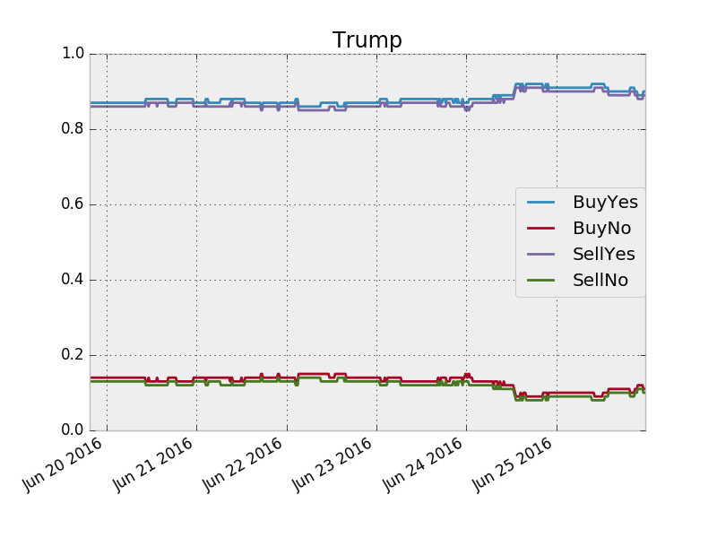

```python
from IPython.display import Image
Image(filename='Market_Histories/RNOM16/Merged/figure20.png')
```

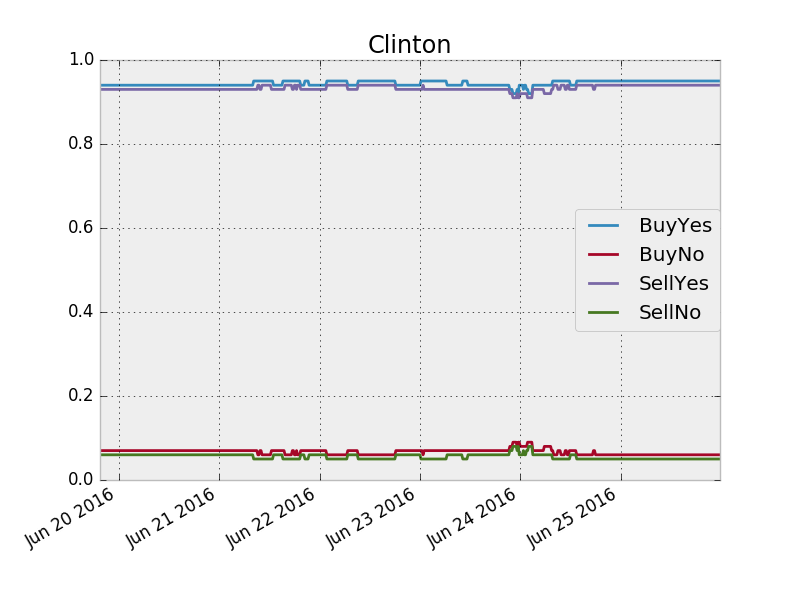

```python
Image(filename='Market_Histories/DNOM16/Merged/figure4.png')
```

These aren't the most intersting plots in the world, and not all markets are as steady as these one, but there are couple things to note that are true of all markets on PredictIt:

1) The Buy price is always above the sell price (this is gauranteed by the format of the markets).

2) The Buy price isn't always exactly 1 cent above the Sell price (trading in fractional pennies isn't allowed, so a 1 cent spread is the minimum).

Now that we have a general idea of how these markets work, let's try to discover some trading strategies that will allow users to make a profit. The strategies that I'll be examing here will meet the following conditions:

- They will require little domain knowledge of the market in question.
- They will not rely on luck.
- They are all ethical (unlike pump and dumps, which are fairly common on PredictIt), and help PredictIt prices better reflect the probabilities of the events in question.

So next, let's look at the "Trump's favorable rate over 33%" market. PredictIt users buy "Yes" if they think that Trump's favorabilty rating (determined by RealClearPolitics.com) will be over 33% on June 22nd and "No" otherwise

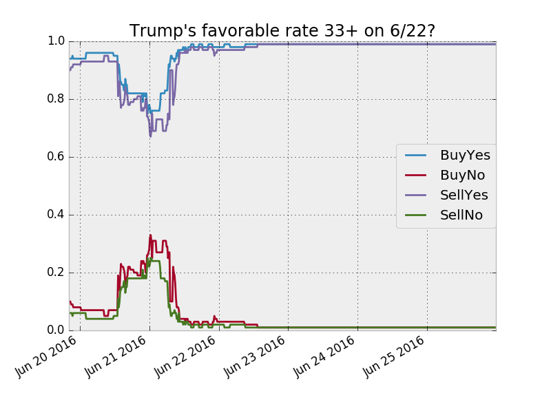

```python
Image(filename='Market_Histories/TRUMP_FAV_062216/Merged/figure1.png')
```

Notice the gap between the Buy and Sell prices? That's referred to as the spread. In the stock market, the spread is almost universally under a fraction of a cent due to High Frequency trading. Here, the spread can grow to 10 cents or more (as it does at the beginning of June 21st on this plot).

## Strategy Number 1: Act like a High Frequency Trading Bot

In non-volatile markets, a paitient buyer can put in an offer to buy at the current *Sell* price, and then offer to sell at the *Buy* price to impatient buyers. When the spread is high, this strategy can allow a user to profit significantly.

The only real way that this strategy fails is when both Buy *and* Sell prices quickly fall. There is a high probability of a low reward, and a low probability of a large loss. In other words, it's a fairly risky strategy, and it is not advisable to use this strategy without a way to reduce your risk.

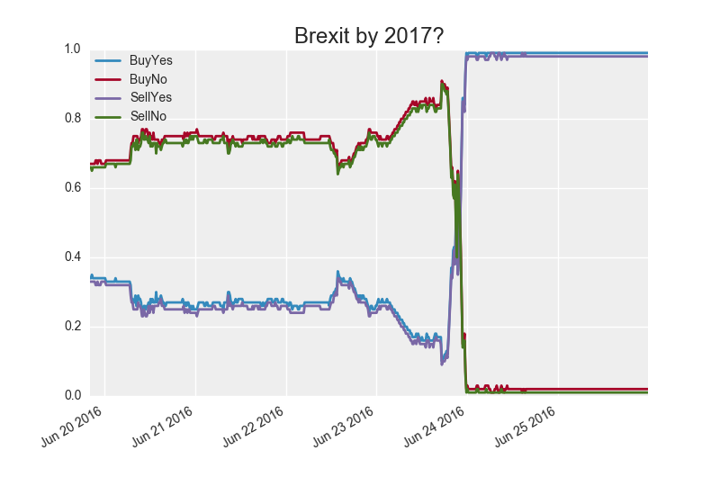

```python
Image(filename='Market_Histories/BREXIT16/Merged/figure1.png')
```

Luckily, this is not the norm. The Brexit vote was a surprise to most people. In less extreme markets, even if the price does fall, it will only lower by a few cents, leading to a small loss. But still, this is a risk that needs to be considered before pursuing this strategy. So what can be done to reduce the risk? In linked markets, there is hope. The fall of one contract's price means a rise in another, so by buying several contracts simultanously, you can protect yourself from a Brexit style shock.

```python
import pandas as pd

df = pd.DataFrame()
df = pd.read_csv('Market_Histories/DNOM16/Merged/DNOM16.csv', sep=',')
df['DateTime'] = df['Date'] +" " + df['Time']
# The DateTime chosen is arbitrary; the relationship that it is intented to show exists throughout most of the dataset.
# Gets all contracts for June 19th, at 7:30 pm in the Democratic Nomination Market
df = df[df['DateTime'] == '06-19-2016 19:30:03']
df[['Contract','BuyYes','BuyNo']]
```

|  | Contract | BuyYes | BuyNo |
| --- | --- | --- | --- |
| 0 | Clinton | 0.94 | 0.07 |
| 1 | Sanders | 0.06 | 0.95 |
| 2 | Biden | 0.04 | 0.97 |
| 3 | Warren | 0.02 | 0.99 |
| 4 | O'Malley | 0.01 | null |
| 5 | Brown | 0.01 | null |
| 6 | de Blasio | 0.01 | null |
| 7 | Webb | 0.01 | null |
| 8 | Chafee | 0.01 | null |
| 9 | Gore | 0.01 | null |

## Strategy Number 2: Buy the "No" contracts, not the "Yes" contract.

Speaking of linked contracts, let's take a look at one of the most persistantly profitiable trading strategy on PredictIt. The important thing to remember about linked contracts here is that they are *mutually exclusive.*

Suppose that you think that Clinton will win the Democratic nomination. With the prices shown above, there are two ways to express that bet.

1) Buy Clinton Yes shares at 94 cents each.

2) Buy Biden No shares at 97 cents, Sanders No shares at 95 cents, and Warren No shares at 99 cents.

In Game Theory terms, option one is Strictly Dominated by option 2. There is simply no rational reason to choose option 1 over option 2. However, this idiosyncrasy occurs in many PredicIt markets. Let's look at the Republican Nomination market.

```python
df = pd.DataFrame()
df = pd.read_csv('Market_Histories/RNOM16/Merged/RNOM16.csv', sep=',')

#Takes the open contracts at June 19th at 7:30 pm
df[['Contract','BuyYes','BuyNo']].iloc[range(7)]
```

|  | Contract | BuyYes | BuyNo |
| --- | --- | --- | --- |
| 0 | Trump | 0.87 | 0.14 |
| 1 | Ryan | 0.07 | 0.94 |
| 2 | Cruz | 0.05 | 0.96 |
| 3 | Walker | 0.03 | 0.98 |
| 4 | Kasich | 0.03 | 0.98 |
| 5 | Rubio | 0.02 | 0.99 |
| 6 | Romney | 0.03 | 0.98 |

Here, the same relationship exists. It cost 87 cents to buy Trump "Yes", but only 83 cents to buy "No" for everyone else. It's pretty amazing how often this happens. Since the market never seems to correct itself, a quick flip (like in the spread strategy discussed above) is out of the question.

However, a user who employs this strategy will be able to make around an extra 3-5% in these markets at the time that it pays out.

The risk here lies in the fact that you are still betting on an outcome, and can still lose money. However, this strategy provides the higher payoff when you are correct, and a lower loss if you're not correct.

But then the quesetion remains, is there a way to eliminate that risk completely?

## Strategy Number 3: Negative Risk

Let's try something strange. Let's buy No for everyone besides Trump, and then buy No for Trump too. It would cost an extra 14 cents per share, bringing the total to 97 cents, with a gauranteed 1 dollar payout. It doesn't seem to make any sense, because you're betting against everyone becoming the Republican nominee. So why does it work? Because the market is mispriced.

Let's sum up all of the "BuyYes" prices (.87 + .07 + .05 + .03 + .03 + .02 + .03) = 1.10. So that means that according to PredictIt, the probability of either Trump, Ryan, Cruz, Walker, Kasich, Rubio, or Romney winning the Republican Primary is 110%. But since probabilities must sum to 1, this is a flaw in the market that can be corrected for by betting "No" on everyone.

On PredictIt, your "risk" is the higest amount of money that you can lose. By following this strategy, your risk actually turns negative, and your PredictIt account is automatically credited. The downside is that this strategy can only be used in markets where the "Yes" prices sum to a value greater than 1 dollar.

Surprisingly, the most popular markets are often the ones that are mispriced. Perhaps this is due to less careful PredictIt users participating without closely examining the prices. Let's look at the most popular market this year, the "Who will win the US Presidential Race" market.

```python
%matplotlib inline
import seaborn

file_df  = pd.read_csv("Other\\USPREZ16.csv", parse_dates=['Date'])

# find the percentage of linked markets that have price sums greater than 1.00
file_df['Price_sum'] = file_df['Clinton_Price'] + file_df['Trump_Price'] + file_df['Johnson_Price']
pct_gt_100 = (len(file_df[file_df['Price_sum'] > 100]) / len(file_df))*100
print("{0:.0f}%".format(pct_gt_100) + " of Buy Yes prices are greater than $1")
```

```
90% of Buy Yes prices are greater than $1
```

In this market, 90% of the time, the sum of the "Yes" prices is above $1.00, meaning that negative risk is avalaible. By looking at the violin plot below, you can easily see how unoften the price in this market is set correctly at 100 cents, which is comprable to a 100% probability.

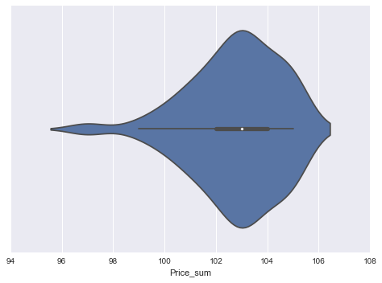

```python
seaborn.violinplot(data= file_df, x = 'Price_sum')
```

## Conclusion

There are a few strategies that a person can follow that can increase the probability of making a profit on PredictIt. Depending on the situation, one can act like a HFT bot, buy "No" contracts for all except one contract, or pursue Negative Risk by buying "No" on all contracts. Each of these comes with their own risks and rewards, and should be pursued with caution.